# Holtemme WGCNA network selection

Camilo Escobar

# 1 Purpose and decision framework

This report tests whether the current WGCNA network is sensitive to retaining the 5,000, 10,000, or 15,000 most variable genes. It reconstructs each network from the same 30 individual RNA-seq libraries while keeping the correlation method, network type, module-detection settings, and planned site contrasts fixed. The soft-thresholding power is re-evaluated separately for each gene set because the connectivity distribution changes when additional genes enter the network.

The comparison is not designed to select the network with the highest scale-free-topology fit alone. The final gene set should balance network connectivity, module assignment, preservation of modules across nested gene sets, site-stratified resampling stability, and computational reproducibility. Annotation coverage is a secondary practical criterion. Site-contrast significance, DEG overlap, enrichment yield, and chemistry are downstream sensitivity results and cannot determine network parameters. Gene-set preservation in this report is a feature-selection sensitivity analysis and does not replace the site-stratified resampling analysis required to evaluate module robustness.

# 2 0. Setup and configuration

# 3 1. Input manifest

Inputs for the WGCNA gene-set sensitivity analysis.

| input_id | path | required | role | present |
| --- | --- | --- | --- | --- |
| vst_expression | ../Results_01_Global_Transcriptome_Structure/matrices/vst_matrix_germany.tsv | TRUE | gene-level VST expression matrix | TRUE |
| matched_metadata | ../Results_01_Global_Transcriptome_Structure/tables/metadata_matched_germany.csv | TRUE | sample and site metadata | TRUE |
| station_crosswalk | ../01_metadata/station_crosswalk.csv | TRUE | station order and site labels | TRUE |
| collapsed_annotation | ../Results_03_Differential_Expression/tables/gene_annotation_collapsed_from_trinotate.csv | FALSE | gene annotation coverage | TRUE |
| aggregate_reference_degs | ../Results_03_Differential_Expression/tables/reference_significant_deg_table.csv | FALSE | reference-only DEG aggregate retained for provenance; not used here | TRUE |
| primary_gene_to_go | ../Results_04_EchoGO_Seed_Preparation/derived_inputs/gene_to_go_primary_eggnog_long.csv | FALSE | GO-mapping coverage | TRUE |
| focal_degs_HOL02_vs_HOL01 | ../Results_03_Differential_Expression/contrast_tables/HOL02_vs_HOL01/HOL02_vs_HOL01_significant_DEGs.csv | TRUE | required DEG source for HOL02 versus HOL01 | TRUE |
| focal_degs_HOL05_vs_HOL04 | ../Results_03_Differential_Expression/contrast_tables/HOL05_vs_HOL04/HOL05_vs_HOL04_significant_DEGs.csv | TRUE | required DEG source for HOL05 versus HOL04 | TRUE |
| focal_degs_HOL06_vs_HOL01 | ../Results_03_Differential_Expression/contrast_tables/HOL06_vs_HOL01/HOL06_vs_HOL01_significant_DEGs.csv | TRUE | required DEG source for HOL06 versus HOL01 | TRUE |

# 4 2. Load and rank the expression matrix

Genes are ranked once by variance across all 30 VST libraries. The 5,000-, 10,000-, and 15,000-gene networks are therefore nested and differ only by the number of lower-ranked genes admitted to the network. Site labels are not used for feature selection.

Expression input and sensitivity-design summary.

| raw_vst_gene_n | unique_gene_n | nonzero_variance_gene_n | sample_n | tested_gene_sets | maximum_block_size |
| --- | --- | --- | --- | --- | --- |
| 151508 | 151508 | 151508 | 30 | 5000 \| 10000 \| 15000 | 6000 |

# 5 3. Reconstruct the networks

Each network uses the same signed biweight-midcorrelation design. The soft-thresholding power is selected independently using the current Step 02 rule: the lowest tested power reaching the target is retained; when the target is not reached, the power with the highest available fit is used. Diagnostics at power 12 are also retained so that the effect of adding genes can be compared at a common power.

```
## Reusing validated cache for G5000
```

```
## Reusing validated cache for G10000
```

```
## Reusing validated cache for G15000
```

WGCNA diagnostics across the tested gene-set sizes.

| network_label | requested_gene_n | retained_gene_n | retained_sample_n | selected_power | selected_power_rule | selected_scale_free_fit | selected_slope | selected_mean_connectivity | selected_median_connectivity | target_reached | reference_power_scale_free_fit | reference_power_mean_connectivity | n_assigned_modules | n_assigned_genes | assigned_gene_fraction | n_grey_genes | grey_gene_fraction | median_assigned_module_size | minimum_assigned_module_size | maximum_assigned_module_size | n_blocks | max_block_size_setting | n_fdr_supported_contrasts | n_large_nominal_contrasts |
| --- | --- | --- | --- | --- | --- | --- | --- | --- | --- | --- | --- | --- | --- | --- | --- | --- | --- | --- | --- | --- | --- | --- | --- | --- |
| G5000 | 5000 | 5000 | 30 | 12 | highest available scale-free fit; target not reached | 0.5708 | -1.4032 | 83.2391 | 21.3545 | FALSE | 0.5708 | 83.2391 | 13 | 3355 | 0.6710 | 1645 | 0.3290 | 159.0 | 60 | 695 | 1 | 5000 | 4 | 9 |
| G10000 | 10000 | 10000 | 30 | 20 | highest available scale-free fit; target not reached | 0.5734 | -1.1393 | 83.6935 | 2.8056 | FALSE | 0.5004 | 118.3599 | 16 | 5665 | 0.5665 | 4335 | 0.4335 | 227.0 | 95 | 970 | 2 | 6000 | 8 | 13 |
| G15000 | 15000 | 15000 | 30 | 16 | highest available scale-free fit; target not reached | 0.5911 | -1.2720 | 100.5654 | 7.7803 | FALSE | 0.5179 | 131.7427 | 20 | 8564 | 0.5709 | 6436 | 0.4291 | 360.5 | 91 | 1220 | 3 | 6000 | 4 | 16 |

# 6 4. Soft-threshold and connectivity diagnostics

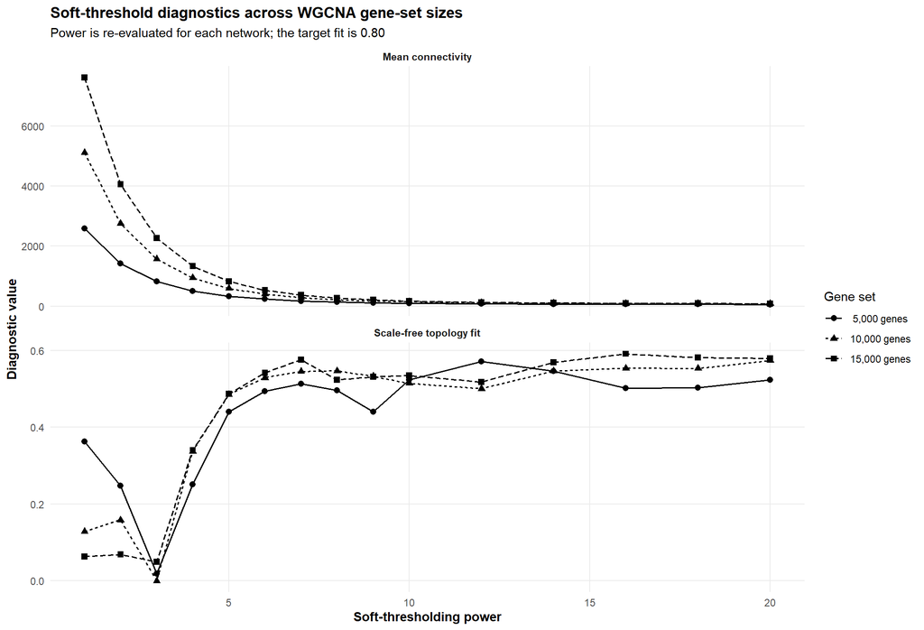

Network diagnostics at the common soft-thresholding power 12 .

| network_label | requested_gene_n | power | scale_free_fit | slope | mean_connectivity | median_connectivity | max_connectivity |
| --- | --- | --- | --- | --- | --- | --- | --- |
| G5000 | 5000 | 12 | 0.5708 | -1.4032 | 83.2391 | 21.3545 | 464.4439 |
| G10000 | 10000 | 12 | 0.5004 | -1.5766 | 118.3599 | 27.0130 | 799.3025 |
| G15000 | 15000 | 12 | 0.5179 | -1.6453 | 131.7427 | 31.5963 | 1031.0038 |

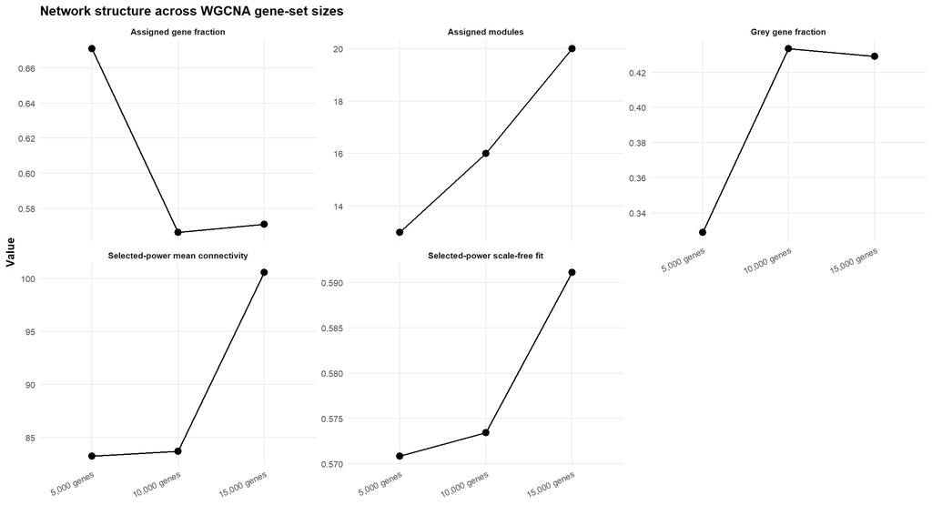

# 7 5. Preservation of modules across nested gene sets

Reference modules are matched to modules in the larger network after restricting both assignments to their shared genes. Jaccard similarity measures overlap in gene membership. Eigengene-profile correlation measures whether the matched modules retain the same dominant expression pattern across the 30 libraries; its absolute value is reported because eigengene signs are arbitrary. The high/moderate/low classes are transparent heuristics for screening and are not formal WGCNA preservation statistics.

Module preservation across nested WGCNA gene sets.

| reference_network | test_network | reference_size | test_size | n_reference_modules | median_jaccard | minimum_jaccard | median_reference_recovery | median_abs_eigengene_cor | n_high_preservation | n_moderate_preservation | n_low_preservation |
| --- | --- | --- | --- | --- | --- | --- | --- | --- | --- | --- | --- |
| G10000 | G15000 | 10000 | 15000 | 16 | 0.4536 | 0.0893 | 0.6624 | 0.9799 | 5 | 5 | 6 |
| G5000 | G10000 | 5000 | 10000 | 13 | 0.6061 | 0.1881 | 0.7841 | 0.9901 | 7 | 3 | 3 |
| G5000 | G15000 | 5000 | 15000 | 13 | 0.5474 | 0.1462 | 0.7513 | 0.9870 | 4 | 7 | 2 |

Best module matches based on shared-gene Jaccard similarity.

| reference_network | test_network | reference_size | test_size | reference_module | reference_module_label | test_module | test_module_label | reference_module_shared_n | reference_to_test_grey_n | reference_to_test_grey_fraction | intersection_n | union_n | jaccard | reference_recovery_fraction | test_purity_fraction | eigengene_profile_cor | eigengene_profile_abs_cor | preservation_class |
| --- | --- | --- | --- | --- | --- | --- | --- | --- | --- | --- | --- | --- | --- | --- | --- | --- | --- | --- |
| G5000 | G10000 | 5000 | 10000 | brown | MEbrown | brown | MEbrown | 432 | 38 | 0.0880 | 378 | 440 | 0.8591 | 0.8750 | 0.9793 | 0.9975 | 0.9975 | high |
| G5000 | G10000 | 5000 | 10000 | turquoise | MEturquoise | turquoise | MEturquoise | 695 | 45 | 0.0647 | 544 | 698 | 0.7794 | 0.7827 | 0.9945 | 0.9947 | 0.9947 | high |
| G5000 | G10000 | 5000 | 10000 | yellow | MEyellow | yellow | MEyellow | 362 | 27 | 0.0746 | 314 | 421 | 0.7458 | 0.8674 | 0.8418 | 0.9979 | 0.9979 | high |
| G5000 | G10000 | 5000 | 10000 | green | MEgreen | green | MEgreen | 233 | 22 | 0.0944 | 196 | 263 | 0.7452 | 0.8412 | 0.8673 | 0.9977 | 0.9977 | high |
| G5000 | G10000 | 5000 | 10000 | blue | MEblue | blue | MEblue | 579 | 56 | 0.0967 | 454 | 629 | 0.7218 | 0.7841 | 0.9008 | 0.9989 | 0.9989 | high |
| G5000 | G10000 | 5000 | 10000 | salmon | MEsalmon | magenta | MEmagenta | 60 | 6 | 0.1000 | 54 | 88 | 0.6136 | 0.9000 | 0.6585 | 0.9960 | 0.9960 | high |
| G5000 | G10000 | 5000 | 10000 | purple | MEpurple | purple | MEpurple | 144 | 10 | 0.0694 | 100 | 165 | 0.6061 | 0.6944 | 0.8264 | 0.9810 | 0.9810 | high |
| G5000 | G10000 | 5000 | 10000 | pink | MEpink | red | MEred | 155 | 25 | 0.1613 | 124 | 214 | 0.5794 | 0.8000 | 0.6776 | 0.9781 | 0.9781 | moderate |
| G5000 | G10000 | 5000 | 10000 | greenyellow | MEgreenyellow | black | MEblack | 99 | 21 | 0.2121 | 76 | 147 | 0.5170 | 0.7677 | 0.6129 | 0.9888 | 0.9888 | moderate |
| G5000 | G10000 | 5000 | 10000 | tan | MEtan | pink | MEpink | 87 | 9 | 0.1034 | 71 | 148 | 0.4797 | 0.8161 | 0.5379 | 0.9901 | 0.9901 | moderate |
| G5000 | G10000 | 5000 | 10000 | red | MEred | greenyellow | MEgreenyellow | 196 | 79 | 0.4031 | 82 | 223 | 0.3677 | 0.4184 | 0.7523 | 0.9803 | 0.9803 | low |
| G5000 | G10000 | 5000 | 10000 | magenta | MEmagenta | tan | MEtan | 154 | 31 | 0.2013 | 60 | 169 | 0.3550 | 0.3896 | 0.8000 | 0.9242 | 0.9242 | low |
| G5000 | G10000 | 5000 | 10000 | black | MEblack | cyan | MEcyan | 159 | 109 | 0.6855 | 38 | 202 | 0.1881 | 0.2390 | 0.4691 | 0.6457 | 0.6457 | low |
| G5000 | G15000 | 5000 | 15000 | brown | MEbrown | brown | MEbrown | 432 | 49 | 0.1134 | 348 | 438 | 0.7945 | 0.8056 | 0.9831 | 0.9968 | 0.9968 | high |
| G5000 | G15000 | 5000 | 15000 | turquoise | MEturquoise | turquoise | MEturquoise | 695 | 36 | 0.0518 | 533 | 701 | 0.7603 | 0.7669 | 0.9889 | 0.9925 | 0.9925 | high |
| G5000 | G15000 | 5000 | 15000 | green | MEgreen | yellow | MEyellow | 233 | 34 | 0.1459 | 179 | 252 | 0.7103 | 0.7682 | 0.9040 | 0.9960 | 0.9960 | high |
| G5000 | G15000 | 5000 | 15000 | blue | MEblue | blue | MEblue | 579 | 47 | 0.0812 | 435 | 645 | 0.6744 | 0.7513 | 0.8683 | 0.9961 | 0.9961 | high |
| G5000 | G15000 | 5000 | 15000 | pink | MEpink | purple | MEpurple | 155 | 27 | 0.1742 | 103 | 177 | 0.5819 | 0.6645 | 0.8240 | 0.9652 | 0.9652 | moderate |
| G5000 | G15000 | 5000 | 15000 | tan | MEtan | cyan | MEcyan | 87 | 13 | 0.1494 | 69 | 124 | 0.5565 | 0.7931 | 0.6509 | 0.9897 | 0.9897 | moderate |
| G5000 | G15000 | 5000 | 15000 | greenyellow | MEgreenyellow | pink | MEpink | 99 | 20 | 0.2020 | 75 | 137 | 0.5474 | 0.7576 | 0.6637 | 0.9870 | 0.9870 | moderate |
| G5000 | G15000 | 5000 | 15000 | magenta | MEmagenta | salmon | MEsalmon | 154 | 16 | 0.1039 | 88 | 182 | 0.4835 | 0.5714 | 0.7586 | 0.9702 | 0.9702 | moderate |
| G5000 | G15000 | 5000 | 15000 | yellow | MEyellow | green | MEgreen | 362 | 26 | 0.0718 | 193 | 449 | 0.4298 | 0.5331 | 0.6893 | 0.9255 | 0.9255 | moderate |
| G5000 | G15000 | 5000 | 15000 | purple | MEpurple | red | MEred | 144 | 21 | 0.1458 | 90 | 215 | 0.4186 | 0.6250 | 0.5590 | 0.8906 | 0.8906 | moderate |
| G5000 | G15000 | 5000 | 15000 | salmon | MEsalmon | black | MEblack | 60 | 7 | 0.1167 | 48 | 120 | 0.4000 | 0.8000 | 0.4444 | 0.9928 | 0.9928 | moderate |
| G5000 | G15000 | 5000 | 15000 | red | MEred | grey60 | MEgrey60 | 196 | 58 | 0.2959 | 73 | 221 | 0.3303 | 0.3724 | 0.7449 | 0.9574 | 0.9574 | low |
| G5000 | G15000 | 5000 | 15000 | black | MEblack | green | MEgreen | 159 | 90 | 0.5660 | 56 | 383 | 0.1462 | 0.3522 | 0.2000 | 0.8394 | 0.8394 | low |
| G10000 | G15000 | 10000 | 15000 | turquoise | MEturquoise | turquoise | MEturquoise | 970 | 43 | 0.0443 | 888 | 1015 | 0.8749 | 0.9155 | 0.9518 | 0.9995 | 0.9995 | high |
| G10000 | G15000 | 10000 | 15000 | brown | MEbrown | brown | MEbrown | 730 | 57 | 0.0781 | 630 | 769 | 0.8192 | 0.8630 | 0.9417 | 0.9993 | 0.9993 | high |
| G10000 | G15000 | 10000 | 15000 | green | MEgreen | yellow | MEyellow | 426 | 41 | 0.0962 | 336 | 467 | 0.7195 | 0.7887 | 0.8912 | 0.9981 | 0.9981 | high |
| G10000 | G15000 | 10000 | 15000 | blue | MEblue | blue | MEblue | 903 | 50 | 0.0554 | 705 | 1098 | 0.6421 | 0.7807 | 0.7833 | 0.9962 | 0.9962 | high |
| G10000 | G15000 | 10000 | 15000 | red | MEred | purple | MEpurple | 379 | 65 | 0.1715 | 246 | 409 | 0.6015 | 0.6491 | 0.8913 | 0.9875 | 0.9875 | high |
| G10000 | G15000 | 10000 | 15000 | black | MEblack | pink | MEpink | 279 | 55 | 0.1971 | 194 | 352 | 0.5511 | 0.6953 | 0.7266 | 0.9942 | 0.9942 | moderate |
| G10000 | G15000 | 10000 | 15000 | pink | MEpink | cyan | MEcyan | 252 | 68 | 0.2698 | 157 | 287 | 0.5470 | 0.6230 | 0.8177 | 0.9955 | 0.9955 | moderate |
| G10000 | G15000 | 10000 | 15000 | salmon | MEsalmon | midnightblue | MEmidnightblue | 122 | 12 | 0.0984 | 73 | 156 | 0.4679 | 0.5984 | 0.6822 | 0.9289 | 0.9289 | moderate |
| G10000 | G15000 | 10000 | 15000 | magenta | MEmagenta | black | MEblack | 202 | 38 | 0.1881 | 141 | 321 | 0.4393 | 0.6980 | 0.5423 | 0.9927 | 0.9927 | moderate |
| G10000 | G15000 | 10000 | 15000 | purple | MEpurple | red | MEred | 180 | 15 | 0.0833 | 147 | 342 | 0.4298 | 0.8167 | 0.4757 | 0.9448 | 0.9448 | moderate |
| G10000 | G15000 | 10000 | 15000 | yellow | MEyellow | green | MEgreen | 590 | 32 | 0.0542 | 283 | 730 | 0.3877 | 0.4797 | 0.6690 | 0.9092 | 0.9092 | low |
| G10000 | G15000 | 10000 | 15000 | cyan | MEcyan | lightyellow | MElightyellow | 119 | 41 | 0.3445 | 48 | 150 | 0.3200 | 0.4034 | 0.6076 | 0.8233 | 0.8233 | low |
| G10000 | G15000 | 10000 | 15000 | midnightblue | MEmidnightblue | salmon | MEsalmon | 111 | 17 | 0.1532 | 75 | 240 | 0.3125 | 0.6757 | 0.3676 | 0.9151 | 0.9151 | low |
| G10000 | G15000 | 10000 | 15000 | greenyellow | MEgreenyellow | grey60 | MEgrey60 | 175 | 20 | 0.1143 | 72 | 236 | 0.3051 | 0.4114 | 0.5414 | 0.9724 | 0.9724 | low |
| G10000 | G15000 | 10000 | 15000 | tan | MEtan | salmon | MEsalmon | 132 | 16 | 0.1212 | 60 | 276 | 0.2174 | 0.4545 | 0.2941 | 0.8550 | 0.8550 | low |
| G10000 | G15000 | 10000 | 15000 | lightcyan | MElightcyan | magenta | MEmagenta | 95 | 11 | 0.1158 | 30 | 336 | 0.0893 | 0.3158 | 0.1107 | 0.7502 | 0.7502 | low |

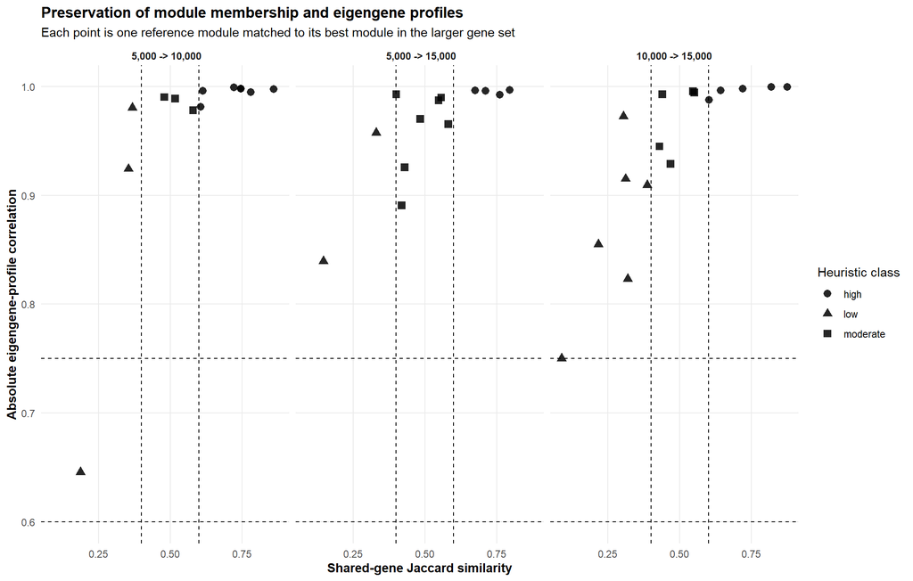

# 8 6. Preservation of planned site-contrast signals

The three planned contrasts are fitted separately within each reconstructed network using the individual-library module eigengenes. Benjamini-Hochberg correction is applied across all module-by-contrast tests within each network. Because module labels and eigengene signs are arbitrary across networks, direct cross-network effect comparisons are made only for the best-matched modules and the test-network effect is aligned to the sign of the eigengene-profile correlation.

Planned module-contrast evidence across gene-set sizes.

[output not shown]

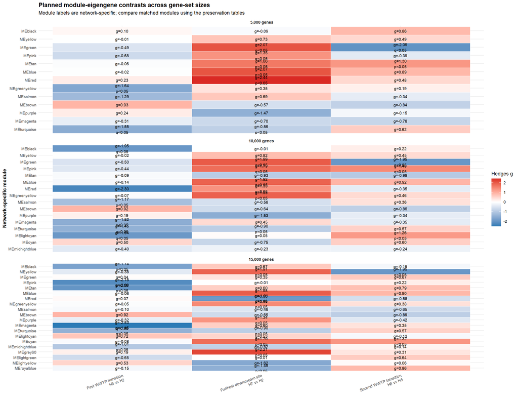

# 9 7. DEG and annotation coverage

Increasing the gene set can improve biological coverage even when the scale-free-topology fit does not improve. This section records how many focal DEGs, annotated genes, and GO-mapped genes are eligible for the network and how many are retained in assigned modules. These diagnostics do not use DEG status or annotation to construct the network.

Readable annotation and GO-mapping coverage across gene sets.

| network_label | network_size | eligible_gene_n | assigned_gene_n | readable_annotation_eligible_n | readable_annotation_assigned_n | go_mapped_eligible_n | go_mapped_assigned_n | readable_annotation_eligible_fraction | readable_annotation_assigned_fraction | go_mapped_eligible_fraction | go_mapped_assigned_fraction |
| --- | --- | --- | --- | --- | --- | --- | --- | --- | --- | --- | --- |
| G5000 | 5000 | 5000 | 3355 | 755 | 714 | 556 | 531 | 0.1510 | 0.2128 | 0.1112 | 0.1583 |
| G10000 | 10000 | 10000 | 5665 | 1325 | 1251 | 994 | 949 | 0.1325 | 0.2208 | 0.0994 | 0.1675 |
| G15000 | 15000 | 15000 | 8564 | 1744 | 1641 | 1317 | 1256 | 0.1163 | 0.1916 | 0.0878 | 0.1467 |

Coverage of significant genes from the three focal contrasts.

[output not shown]

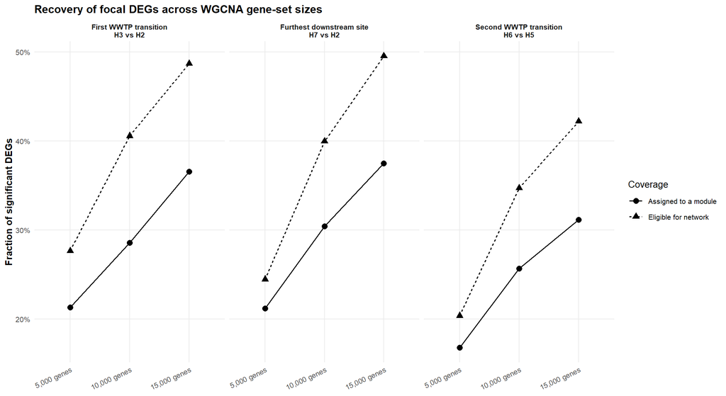

# 10 8. Structural power sensitivity for the 10,000-gene candidate

The 10,000-gene candidate is reconstructed at powers 12, 14, 16, 18, and 20 with every other network setting fixed. Selection uses connectivity, module assignment, adjacent-power preservation, and site-stratified resampling only. Site contrasts, DEG overlap, enrichment yield, and chemistry are not available to the power-selection rule.

```
## Reusing 10,000-gene power cache: 12
```

```
## Reusing 10,000-gene power cache: 14
```

```
## Reusing 10,000-gene power cache: 16
```

```
## Reusing 10,000-gene power cache: 18
```

```
## Reusing 10,000-gene power cache: 20
```

```
## Reusing power/resample cache P12 R1
```

```
## Reusing power/resample cache P12 R2
```

```
## Reusing power/resample cache P12 R3
```

```
## Reusing power/resample cache P12 R4
```

```
## Reusing power/resample cache P12 R5
```

```
## Reusing power/resample cache P12 R6
```

```
## Reusing power/resample cache P12 R7
```

```
## Reusing power/resample cache P12 R8
```

```
## Reusing power/resample cache P12 R9
```

```
## Reusing power/resample cache P12 R10
```

```
## Reusing power/resample cache P14 R1
```

```
## Reusing power/resample cache P14 R2
```

```
## Reusing power/resample cache P14 R3
```

```
## Reusing power/resample cache P14 R4
```

```
## Reusing power/resample cache P14 R5
```

```
## Reusing power/resample cache P14 R6
```

```
## Reusing power/resample cache P14 R7
```

```
## Reusing power/resample cache P14 R8
```

```
## Reusing power/resample cache P14 R9
```

```
## Reusing power/resample cache P14 R10
```

```
## Reusing power/resample cache P16 R1
```

```
## Reusing power/resample cache P16 R2
```

```
## Reusing power/resample cache P16 R3
```

```
## Reusing power/resample cache P16 R4
```

```
## Reusing power/resample cache P16 R5
```

```
## Reusing power/resample cache P16 R6
```

```
## Reusing power/resample cache P16 R7
```

```
## Reusing power/resample cache P16 R8
```

```
## Reusing power/resample cache P16 R9
```

```
## Reusing power/resample cache P16 R10
```

```
## Reusing power/resample cache P18 R1
```

```
## Reusing power/resample cache P18 R2
```

```
## Reusing power/resample cache P18 R3
```

```
## Reusing power/resample cache P18 R4
```

```
## Reusing power/resample cache P18 R5
```

```
## Reusing power/resample cache P18 R6
```

```
## Reusing power/resample cache P18 R7
```

```
## Reusing power/resample cache P18 R8
```

```
## Reusing power/resample cache P18 R9
```

```
## Reusing power/resample cache P18 R10
```

```
## Reusing power/resample cache P20 R1
```

```
## Reusing power/resample cache P20 R2
```

```
## Reusing power/resample cache P20 R3
```

```
## Reusing power/resample cache P20 R4
```

```
## Reusing power/resample cache P20 R5
```

```
## Reusing power/resample cache P20 R6
```

```
## Reusing power/resample cache P20 R7
```

```
## Reusing power/resample cache P20 R8
```

```
## Reusing power/resample cache P20 R9
```

```
## Reusing power/resample cache P20 R10
```

Structural decision table for the 10,000-gene network power.

| power | signed_scale_free_fit | slope | mean_connectivity | median_connectivity | connectivity_p10 | connectivity_p90 | proportion_very_low_connectivity | very_low_connectivity_threshold | assigned_gene_fraction | grey_fraction | module_n | minimum_module_size_observed | median_module_size | maximum_module_size | n_blocks | raw_undersized_module_n | median_adjacent_power_jaccard | minimum_adjacent_power_jaccard | median_adjacent_power_eigengene_agreement | median_resampling_jaccard | minimum_resampling_jaccard | median_resampling_eigengene_agreement | reciprocal_match_fraction | candidate_moderate_resampling_module_n | candidate_moderate_resampling_module_fraction | scale_free_fit_deficit_from_tested_maximum | overly_sparse | adequate_connectivity | near_best_scale_free_fit | … |
| --- | --- | --- | --- | --- | --- | --- | --- | --- | --- | --- | --- | --- | --- | --- | --- | --- | --- | --- | --- | --- | --- | --- | --- | --- | --- | --- | --- | --- | --- | --- |
| 12 | 0.5004 | -1.5766 | 118.3599 | 27.0130 | 11.8129 | 372.4398 | 0.0000 | 1 | 0.5957 | 0.4043 | 16 | 93 | 219.5 | 1027 | 2 | 0 | 0.8922 | 0.7484 | 0.9995 | 0.4419 | 0.0051 | 0.9883 | 0.8500 | 5 | 0.3125 | 0.0731 | FALSE | TRUE | FALSE | … |
| 14 | 0.5466 | -1.3907 | 102.5095 | 13.6408 | 5.0954 | 352.2556 | 0.0000 | 1 | 0.6087 | 0.3913 | 18 | 90 | 208.5 | 981 | 2 | 0 | 0.9029 | 0.0192 | 0.9996 | 0.4206 | 0.0101 | 0.9843 | 0.8444 | 5 | 0.2778 | 0.0268 | FALSE | TRUE | TRUE | … |
| 16 | 0.5538 | -1.2697 | 93.4892 | 7.4076 | 2.3081 | 337.5678 | 0.0001 | 1 | 0.6014 | 0.3986 | 17 | 91 | 244.0 | 976 | 2 | 0 | 0.8974 | 0.0192 | 0.9995 | 0.4395 | 0.0102 | 0.9853 | 0.8882 | 5 | 0.2941 | 0.0196 | TRUE | FALSE | TRUE | … |
| 18 | 0.5530 | -1.1933 | 87.7360 | 4.3898 | 1.0942 | 325.5071 | 0.0738 | 1 | 0.5934 | 0.4066 | 16 | 78 | 260.5 | 974 | 2 | 0 | 0.8505 | 0.0096 | 0.9986 | 0.4431 | 0.0093 | 0.9882 | 0.8938 | 4 | 0.2500 | 0.0205 | TRUE | FALSE | TRUE | … |
| 20 | 0.5734 | -1.1393 | 83.6935 | 2.8056 | 0.5411 | 315.5359 | 0.2679 | 1 | 0.5665 | 0.4335 | 16 | 95 | 227.0 | 970 | 2 | 1 | 0.8490 | 0.0096 | 0.9990 | 0.4662 | 0.0113 | 0.9889 | 0.8750 | 5 | 0.3125 | 0.0000 | TRUE | FALSE | TRUE | … |

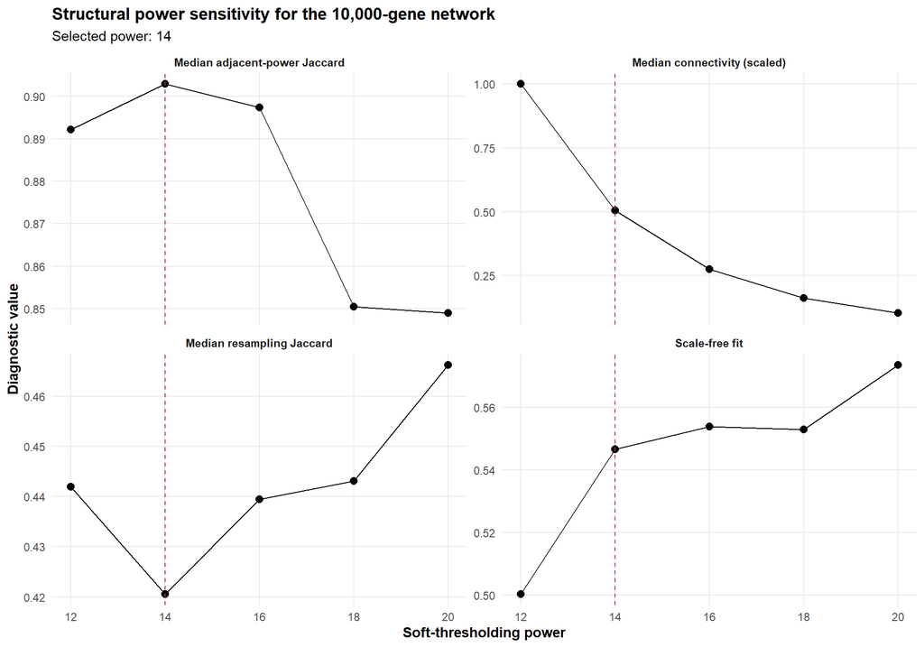

# 11 9. Permitted evidence for network selection

Evidence hierarchy enforced for network selection.

| decision_domain | permitted_for_network_selection | role |
| --- | --- | --- |
| Connectivity and sparsity | Yes | primary structural criterion |
| Module size and grey fraction | Yes | primary structural criterion |
| Resampling stability | Yes | primary structural criterion |
| Cross-universe preservation | Yes | primary structural criterion |
| Annotation coverage | Yes, secondary | practical coverage criterion |
| Number of significant site contrasts | No | downstream sensitivity only |
| DEG overlap | No | downstream sensitivity only |
| GO or KEGG enrichment count | No | downstream sensitivity only |
| Chemistry correlation | No | post-selection exploratory context only |

# 12 10. Final-power cross-universe preservation

The cross-universe confirmation below replaces the provisional 10,000-gene power-20 membership with the structurally selected power-14 membership. This prevents the final gene-universe dashboard from mixing provisional and final network statistics.

Cross-universe preservation after substituting the final 10,000-gene power network.

| reference_network | test_network | reference_size | test_size | n_reference_modules | median_jaccard | minimum_jaccard | median_reference_recovery | median_abs_eigengene_cor | n_high_preservation | n_moderate_preservation | n_low_preservation |
| --- | --- | --- | --- | --- | --- | --- | --- | --- | --- | --- | --- |
| G10000_P14 | G15000 | 10000 | 15000 | 18 | 0.424 | 0.100 | 0.692 | 0.990 | 5 | 5 | 8 |
| G5000 | G10000_P14 | 5000 | 10000 | 13 | 0.615 | 0.306 | 0.786 | 0.991 | 8 | 2 | 3 |

# 13 11. Site-stratified stability across gene universes

The same ten four-of-five-per-site resamples are used to compare the 5,000-, 10,000-, and 15,000-gene candidates. The 10,000-gene reference uses the structurally selected power above; the other universes retain their independently evaluated powers from the nested-universe analysis.

```
## Reusing universe/resample cache G5000 R1
```

```
## Reusing universe/resample cache G5000 R2
```

```
## Reusing universe/resample cache G5000 R3
```

```
## Reusing universe/resample cache G5000 R4
```

```
## Reusing universe/resample cache G5000 R5
```

```
## Reusing universe/resample cache G5000 R6
```

```
## Reusing universe/resample cache G5000 R7
```

```
## Reusing universe/resample cache G5000 R8
```

```
## Reusing universe/resample cache G5000 R9
```

```
## Reusing universe/resample cache G5000 R10
```

```
## Reusing universe/resample cache G15000 R1
```

```
## Reusing universe/resample cache G15000 R2
```

```
## Reusing universe/resample cache G15000 R3
```

```
## Reusing universe/resample cache G15000 R4
```

```
## Reusing universe/resample cache G15000 R5
```

```
## Reusing universe/resample cache G15000 R6
```

```
## Reusing universe/resample cache G15000 R7
```

```
## Reusing universe/resample cache G15000 R8
```

```
## Reusing universe/resample cache G15000 R9
```

```
## Reusing universe/resample cache G15000 R10
```

Site-stratified module stability across nested gene universes.

| network_label | network_size | power | median_resampling_jaccard | minimum_resampling_jaccard | median_eigengene_agreement | reciprocal_match_fraction |
| --- | --- | --- | --- | --- | --- | --- |
| G10000 | 10000 | 14 | 0.421 | 0.010 | 0.984 | 0.844 |
| G15000 | 15000 | 16 | 0.326 | 0.006 | 0.976 | 0.900 |
| G5000 | 5000 | 12 | 0.596 | 0.013 | 0.994 | 0.900 |

# 14 11. Integrated decision dashboard

The decision dashboard contains only structural criteria plus annotation coverage as a secondary practical consideration. Site-contrast significance, DEG recovery, and functional yield are exported in a separate downstream sensitivity table and cannot affect the network choice.

Structural diagnostics for selecting the final WGCNA gene set.

| network_label | network_size | selected_power | selected_scale_free_fit | selected_mean_connectivity | selected_median_connectivity | target_reached | n_assigned_modules | assigned_gene_fraction | grey_gene_fraction | n_blocks | median_jaccard_to_larger | median_abs_eigengene_cor_to_larger | minimum_high_preservation_modules | resampling_power | median_resampling_jaccard | minimum_resampling_jaccard | median_eigengene_agreement | reciprocal_match_fraction | eligible_gene_n | assigned_gene_n | readable_annotation_eligible_n | readable_annotation_assigned_n | go_mapped_eligible_n | go_mapped_assigned_n | readable_annotation_eligible_fraction | readable_annotation_assigned_fraction | go_mapped_eligible_fraction | go_mapped_assigned_fraction |
| --- | --- | --- | --- | --- | --- | --- | --- | --- | --- | --- | --- | --- | --- | --- | --- | --- | --- | --- | --- | --- | --- | --- | --- | --- | --- | --- | --- | --- |
| G5000 | 5000 | 12 | 0.5708 | 83.2391 | 21.3545 | FALSE | 13 | 0.6710 | 0.3290 | 1 | 0.6146 | 0.9915 | 8 | 12 | 0.5961 | 0.0126 | 0.9939 | 0.9000 | 5000 | 3355 | 755 | 714 | 556 | 531 | 0.1510 | 0.2128 | 0.1112 | 0.1583 |
| G10000 | 10000 | 14 | 0.5466 | 102.5095 | 13.6408 | FALSE | 18 | 0.6087 | 0.3913 | 2 | 0.4241 | 0.9902 | 5 | 14 | 0.4206 | 0.0101 | 0.9843 | 0.8444 | 10000 | 6087 | 1325 | 1264 | 994 | 956 | 0.1325 | 0.2077 | 0.0994 | 0.1571 |
| G15000 | 15000 | 16 | 0.5911 | 100.5654 | 7.7803 | FALSE | 20 | 0.5709 | 0.4291 | 3 | NA | NA | NA | 16 | 0.3256 | 0.0057 | 0.9760 | 0.9000 | 15000 | 8564 | 1744 | 1641 | 1317 | 1256 | 0.1163 | 0.1916 | 0.0878 | 0.1467 |

Downstream results excluded from network selection.

| network_label | network_size | n_fdr_supported_module_contrasts | n_large_nominal_module_contrasts | maximum_abs_hedges_g | mean_eligible_deg_fraction | mean_assigned_deg_fraction_of_total | permitted_for_network_selection | role |
| --- | --- | --- | --- | --- | --- | --- | --- | --- |
| G5000 | 5000 | 4 | 9 | 2.4389 | 0.2417 | 0.1976 | FALSE | downstream sensitivity only |
| G10000 | 10000 | 8 | 13 | 2.3047 | 0.3841 | 0.2909 | FALSE | downstream sensitivity only |
| G15000 | 15000 | 4 | 16 | 2.5300 | 0.4681 | 0.3507 | FALSE | downstream sensitivity only |

## 14.1 Selected network for the downstream exploratory rerun

The 10,000-gene universe is selected as the smallest expanded network that retains much of the 5,000-gene structure without the greater fragmentation and weaker incremental preservation of the 15,000-gene expansion. Its improved annotation coverage is a secondary practical benefit. DEG recovery, site significance, enrichment yield, and chemistry do not enter this decision.

WGCNA network selected for the final site-associated module analysis.

| selected_network_label | selected_gene_set_size | selected_power | soft_threshold_target_reached | n_blocks | max_block_size |
| --- | --- | --- | --- | --- | --- |
| G10000 | 10000 | 14 | FALSE | 2 | 6000 |

Evidence retained with the selected-network decision.

| criterion | value | permitted_for_selection |
| --- | --- | --- |
| G5000_to_G10000_median_Jaccard | 0.6146 | TRUE |
| G5000_to_G10000_median_abs_eigengene_correlation | 0.9915 | TRUE |
| G10000_to_G15000_median_Jaccard | 0.4241 | TRUE |
| G10000_to_G15000_low_preservation_modules | 8.0000 | TRUE |
| G5000_median_resampling_Jaccard | 0.5961 | TRUE |
| G10000_median_resampling_Jaccard | 0.4206 | TRUE |
| G15000_median_resampling_Jaccard | 0.3256 | TRUE |
| G5000_GO_mapped_eligible_genes | 556.0000 | secondary |
| G10000_GO_mapped_eligible_genes | 994.0000 | secondary |
| G15000_GO_mapped_eligible_genes | 1317.0000 | secondary |
| G10000_selected_power | 14.0000 | TRUE |
| G10000_selected_power_median_connectivity | 13.6408 | TRUE |
| G10000_selected_power_median_resampling_Jaccard | 0.4206 | TRUE |

## 14.2 Reading the comparison

None of the tested gene sets reached the prespecified scale-free-topology target. The final network should therefore not be described as scale-free, and gene-set selection should rely on the combined diagnostics rather than on this statistic alone.

The strongest overall cross-size module preservation occurred for the 5,000 to 10,000 comparison (median Jaccard = 0.615; median absolute eigengene correlation = 0.991).

The 10,000-gene universe is selected from structural evidence: cross-universe preservation, site-stratified resampling stability, connectivity, assignment, and module-size behaviour. Annotation coverage is secondary. Site-contrast significance, DEG recovery, enrichment yield, and chemistry were excluded from selection. Within the 10,000-gene universe, power 14 is the lowest candidate meeting the declared connectivity, scale-free-fit-deficit, and resampling-stability criteria. Step 08 consumes this explicit final-network handoff.

# 15 9. Save the lightweight comparison object

# 16 10. Output inventory and session information

Outputs generated by the WGCNA gene-set sensitivity report.

| relative_path | size_bytes |
| --- | --- |
| logs/session_info.txt | 2626 |
| objects/G10000_network_result_cache.rds | 1229053 |
| objects/G15000_network_result_cache.rds | 1839216 |
| objects/G5000_network_result_cache.rds | 621654 |
| objects/gene_universe_resample_cache/G15000_resample_01_111cb70bb8eec4f6.rds | 5703 |
| objects/gene_universe_resample_cache/G15000_resample_01_1b3c552ac70fb116.rds | 5890 |
| objects/gene_universe_resample_cache/G15000_resample_02_2845a5b384144911.rds | 5919 |
| objects/gene_universe_resample_cache/G15000_resample_02_5d720c91aecc87ac.rds | 5732 |
| objects/gene_universe_resample_cache/G15000_resample_03_6ceac14d9e529601.rds | 5908 |
| objects/gene_universe_resample_cache/G15000_resample_03_b96d0185ac660a27.rds | 5721 |
| objects/gene_universe_resample_cache/G15000_resample_04_38ae3a92eed97766.rds | 5911 |
| objects/gene_universe_resample_cache/G15000_resample_04_4743d9c7bcd37777.rds | 5724 |
| objects/gene_universe_resample_cache/G15000_resample_05_466bdc63b496ea2e.rds | 5734 |
| objects/gene_universe_resample_cache/G15000_resample_05_a7f84e4ff9989319.rds | 5921 |
| objects/gene_universe_resample_cache/G15000_resample_06_5a9ed8eb379eadde.rds | 5728 |
| objects/gene_universe_resample_cache/G15000_resample_06_f580b7adbacea1f0.rds | 5915 |
| objects/gene_universe_resample_cache/G15000_resample_07_4c8e0f5b3ad99ee4.rds | 5713 |
| objects/gene_universe_resample_cache/G15000_resample_07_6eb77654b9668376.rds | 5900 |
| objects/gene_universe_resample_cache/G15000_resample_08_172470aee6791702.rds | 5863 |
| objects/gene_universe_resample_cache/G15000_resample_08_bbfe2918bc99d531.rds | 5676 |
| objects/gene_universe_resample_cache/G15000_resample_09_1b405d85a2c5ab5f.rds | 5893 |
| objects/gene_universe_resample_cache/G15000_resample_09_8663e5ef36fad1ad.rds | 5706 |
| objects/gene_universe_resample_cache/G15000_resample_10_3cd6233824e81630.rds | 5685 |
| objects/gene_universe_resample_cache/G15000_resample_10_3ed811a050f3c810.rds | 5872 |
| objects/gene_universe_resample_cache/G5000_resample_01_7542bf7d9f363c27.rds | 4398 |
| objects/gene_universe_resample_cache/G5000_resample_01_abfb80d297ab1e3e.rds | 4585 |
| objects/gene_universe_resample_cache/G5000_resample_02_54dd7159bb772914.rds | 4587 |
| objects/gene_universe_resample_cache/G5000_resample_02_92a8ff92f524d88a.rds | 4400 |
| objects/gene_universe_resample_cache/G5000_resample_03_2976415338aec991.rds | 4599 |
| objects/gene_universe_resample_cache/G5000_resample_03_86f77900b7d23c93.rds | 4412 |

[output cut: 208 more lines]